# HW 4: PSY 6302

## Section 3

1. Use a ggplot histogram to examine the data’s normality. Make sure to include relevant names for the x-axis, y-axis, a title or caption, and any color/line types you use.
2. Use the research design and original data source material to determine whether the assumption of independence is met.
- The assumption of independence is not met since several observations from the same subject are in more than one experimental condition (group). Also the distribution of scores do not look normally distributed.
3. Examine the homogeneity of variance assumption for all j groups.
- While not normally distributed, visually the variance of the outcome for all *j* groups looks to be similar. However, we also used Levene’s test on the residuals of the model and see that it was not significant, which means that the variances are more or less equal.
4. Without yet running an ANOVA and directly examining variance components, make a prediction about whether groups differ from one another or not. Use your graphic(s) to justify your answer.
- By looking at the second graph, it seems like Blue will probably have the lowest mean since there are many reported 1’s. Additionally, Green has a lot of scores for 3. Thus, if there are any mean group differences, it would probably between these two groups, but it is hard to say.

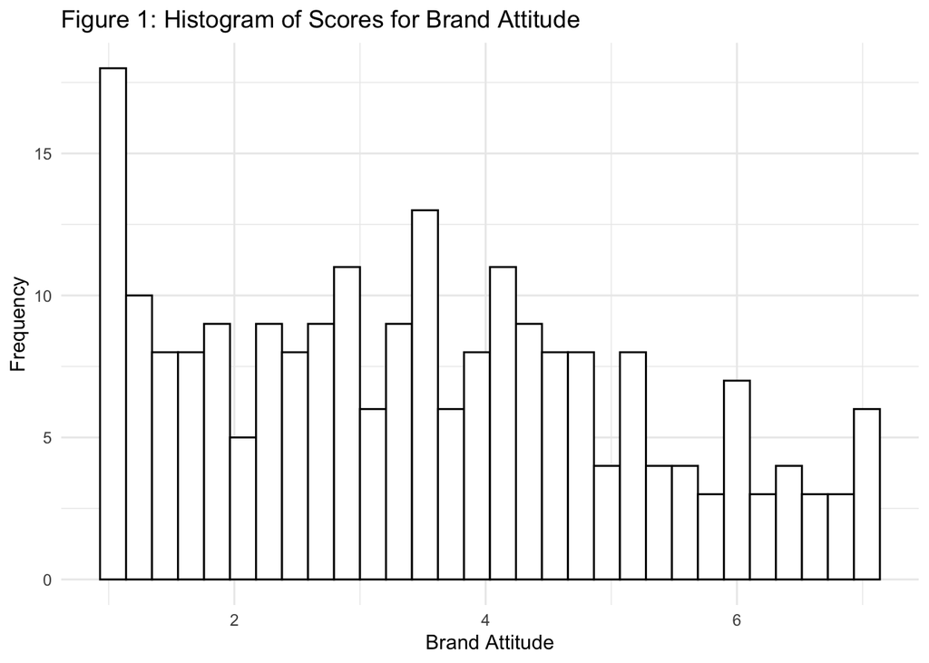

```r
# Create a histogram using ggplot
data %>%
  ggplot(aes(x= Score)) +
  geom_histogram(fill = "white",
                 color = "black") +
  labs(title = "Figure 1: Histogram of Scores for Brand Attitude",
       x = "Brand Attitude",
       y = "Frequency") +
  theme_minimal()
```

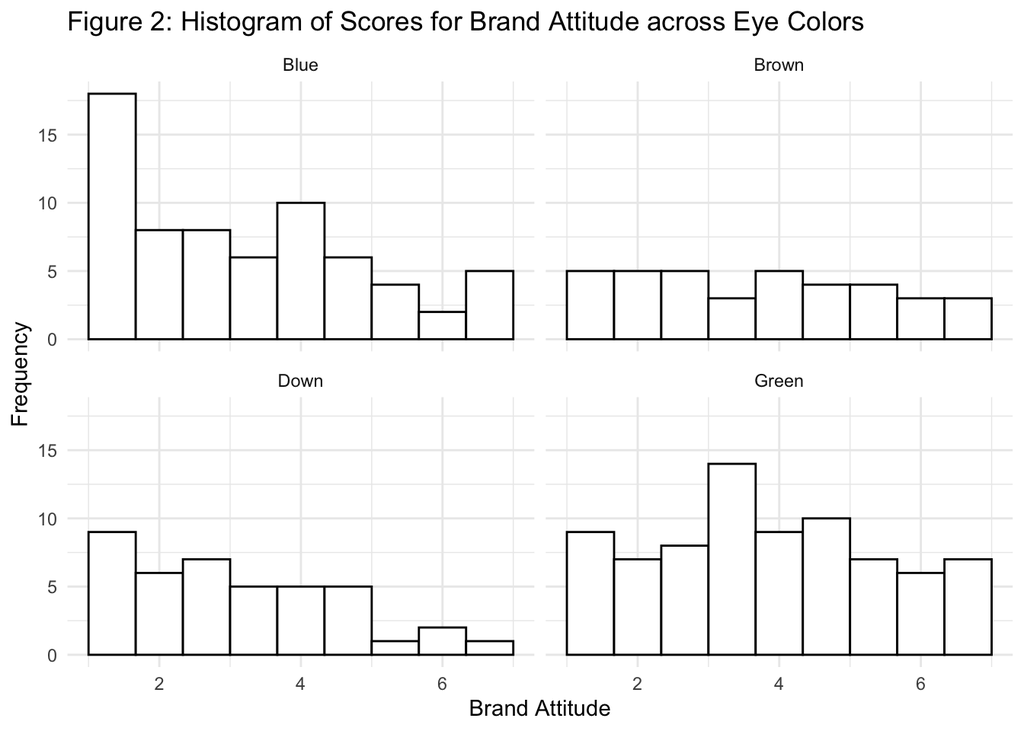

```r
# Plot for homogeneity
data %>%
  ggplot(aes(x= Score)) +
  geom_histogram(fill = "white",
                 color = "black",
                 bins = 10) +
  labs(title = "Figure 2: Histogram of Scores for Brand Attitude across Eye Colors",
       x = "Brand Attitude",
       y = "Frequency") +
  facet_wrap(~Group) +
  theme_minimal()
```

```r
# Create a model for a one-way ANOVA to test the variance of the residuals.
aov_model <- aov(Score~Group, data)

# Run Levene's Test
leveneTest(aov_model, center = median)
```

```
Levene's Test for Homogeneity of Variance (center = median)
       Df F value Pr(>F)
group   3  0.5076 0.6775
      218
```

## Section 4

1. Fit both a restricted and full one-way ANOVA using aov(). Report your code.
2. Fit both a restricted and full one-way ANOVA using lm(). Report your code.
3. Using either the aov() or lm() model outputs, compare the fit between the restricted and full models. Report your code and output.
- The output of the anova() function that does the model comparison is printed below.
4. Based on your comparison, which model should you choose to interpret?
- The output of the model comparison using the anova() function shows that the full model is better than the restricted model since the p-value associated with the test is less than .05. Additionally, we see that the residual sum of squares for the full model is lower than that of the restricted model, indicating it was able to explain more of the variance in the outcome.

```r
# Create the restricted and full One-Way ANOVA Model using aov()
restricted.aov <- aov(Score ~1, data)
full.aov <- aov(Score ~ Group, data)

# Create the restricted and full One-Way ANOVA model using lm()
restricted.lm <- lm(Score ~1, data)
full.lm <- lm(Score ~ Group, data)

# Compare the fit for aov models
anova(restricted.aov, full.aov)
```

```
Analysis of Variance Table

Model 1: Score ~ 1
Model 2: Score ~ Group
  Res.Df    RSS Df Sum of Sq      F  Pr(>F)
1    221 637.56
2    218 613.14  3     24.42 2.8941 0.03618 *
---
Signif. codes:  0 '***' 0.001 '**' 0.01 '*' 0.05 '.' 0.1 ' ' 1
```